# examples_0529

Three people are buying fruit, and there are five grocery stores. Each person has a shopping list dictating how many pounds of each fruit to buy. Each store has different unit costs of fruit.

In order to consider the **total** cost for each person at each store, we can use [matrix multiplication](https://en.wikipedia.org/wiki/Matrix_multiplication). In order to help visualize matrix multiplication, the shopping lists are shown as a matrix on the bottom-left, the unit prices as a matrix on top-right, and the resulting matrix of totals in the bottom-right.

A peculiarity of matrix multiplication requires the **columns** of the first matrix to "match" the **rows** of the second matrix. In this case, notice the various fruits correspond to columns in the first matrix (bottom-left) and rows in the second matrix (top-right). This visualization is an attempt to make this seem more natural.

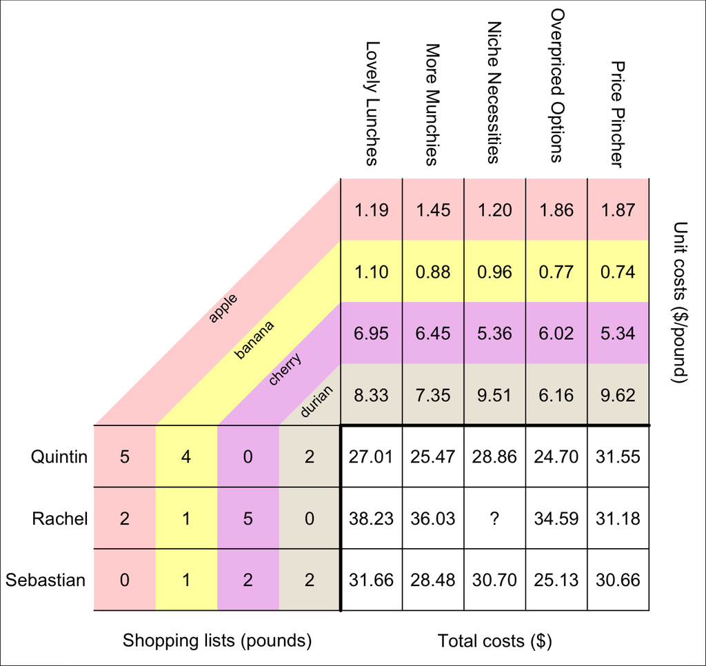

What is the total cost of Rachel shopping at Niche Necessities?

Rachel wishes to buy 2 lb of apple, 1 lb of banana, 5 lb of cherry, and 0 lb of durian. At Niche Necessities, the unit price of apple is $1.20/lb, the unit price of banana is $0.96/lb, the unit price of cherry is $5.36/lb, and the unit price of durian is $9.51/lb.

To find the total cost of Rachel's shopping trip, multiply each quantity by its corresponding unit price and then add up all those products.

$$(2\cdot1.2)~+~(1\cdot0.96)~+~(5\cdot5.36)~+~(0\cdot9.51)$$
$$2.4~+~0.96~+~26.8~+~0$$
$$30.16$$

So, the total cost of Rachel shopping at Niche Necessities is $30.16.

In standard math notation, the matrix multiplication would be shown as:

$$\begin{bmatrix}
5 & 4 & 0 & 2\\
2 & 1 & 5 & 0\\
0 & 1 & 2 & 2
\end{bmatrix} \cdot \begin{bmatrix}
1.19 & 1.45 & 1.2 & 1.86 & 1.87\\
1.1 & 0.88 & 0.96 & 0.77 & 0.74\\
6.95 & 6.45 & 5.36 & 6.02 & 5.34\\
8.33 & 7.35 & 9.51 & 6.16 & 9.62
\end{bmatrix} ~=~ \begin{bmatrix}
27.01 & 25.47 & 28.86 & 24.7 & 31.55\\
38.23 & 36.03 & 30.16 & 34.59 & 31.18\\
31.66 & 28.48 & 30.7 & 25.13 & 30.66
\end{bmatrix}$$

Three people are buying fruit, and there are five grocery stores. Each person has a shopping list dictating how many pounds of each fruit to buy. Each store has different unit costs of fruit.

In order to consider the **total** cost for each person at each store, we can use [matrix multiplication](https://en.wikipedia.org/wiki/Matrix_multiplication). In order to help visualize matrix multiplication, the shopping lists are shown as a matrix on the bottom-left, the unit prices as a matrix on top-right, and the resulting matrix of totals in the bottom-right.

A peculiarity of matrix multiplication requires the **columns** of the first matrix to "match" the **rows** of the second matrix. In this case, notice the various fruits correspond to columns in the first matrix (bottom-left) and rows in the second matrix (top-right). This visualization is an attempt to make this seem more natural.

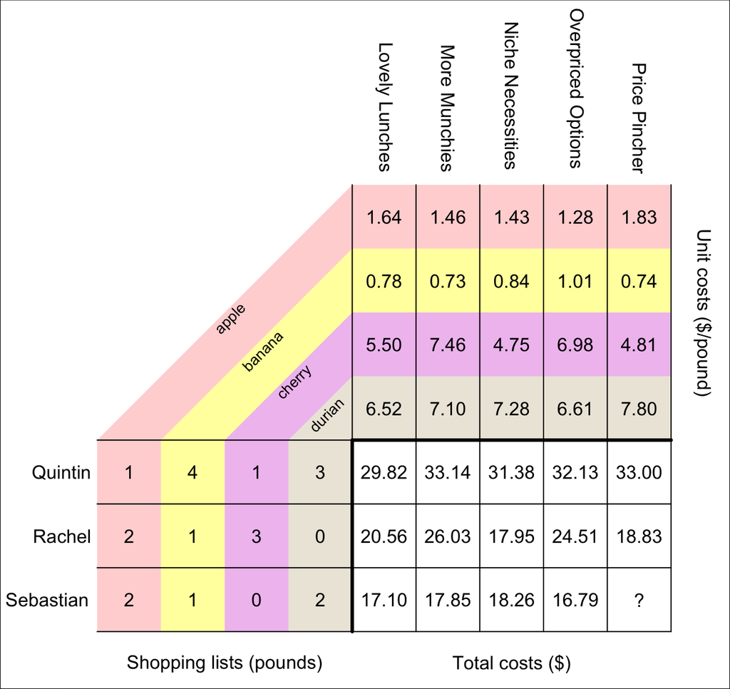

What is the total cost of Sebastian shopping at Price Pincher?

Sebastian wishes to buy 2 lb of apple, 1 lb of banana, 0 lb of cherry, and 2 lb of durian. At Price Pincher, the unit price of apple is $1.83/lb, the unit price of banana is $0.74/lb, the unit price of cherry is $4.81/lb, and the unit price of durian is $7.80/lb.

To find the total cost of Sebastian's shopping trip, multiply each quantity by its corresponding unit price and then add up all those products.

$$(2\cdot1.83)~+~(1\cdot0.74)~+~(0\cdot4.81)~+~(2\cdot7.8)$$
$$3.66~+~0.74~+~0~+~15.6$$
$$20.00$$

So, the total cost of Sebastian shopping at Price Pincher is $20.00.

In standard math notation, the matrix multiplication would be shown as:

$$\begin{bmatrix}
1 & 4 & 1 & 3\\
2 & 1 & 3 & 0\\
2 & 1 & 0 & 2
\end{bmatrix} \cdot \begin{bmatrix}
1.64 & 1.46 & 1.43 & 1.28 & 1.83\\
0.78 & 0.73 & 0.84 & 1.01 & 0.74\\
5.5 & 7.46 & 4.75 & 6.98 & 4.81\\
6.52 & 7.1 & 7.28 & 6.61 & 7.8
\end{bmatrix} ~=~ \begin{bmatrix}
29.82 & 33.14 & 31.38 & 32.13 & 33\\
20.56 & 26.03 & 17.95 & 24.51 & 18.83\\
17.1 & 17.85 & 18.26 & 16.79 & 20
\end{bmatrix}$$

Three people are buying fruit, and there are five grocery stores. Each person has a shopping list dictating how many pounds of each fruit to buy. Each store has different unit costs of fruit.

In order to consider the **total** cost for each person at each store, we can use [matrix multiplication](https://en.wikipedia.org/wiki/Matrix_multiplication). In order to help visualize matrix multiplication, the shopping lists are shown as a matrix on the bottom-left, the unit prices as a matrix on top-right, and the resulting matrix of totals in the bottom-right.

A peculiarity of matrix multiplication requires the **columns** of the first matrix to "match" the **rows** of the second matrix. In this case, notice the various fruits correspond to columns in the first matrix (bottom-left) and rows in the second matrix (top-right). This visualization is an attempt to make this seem more natural.

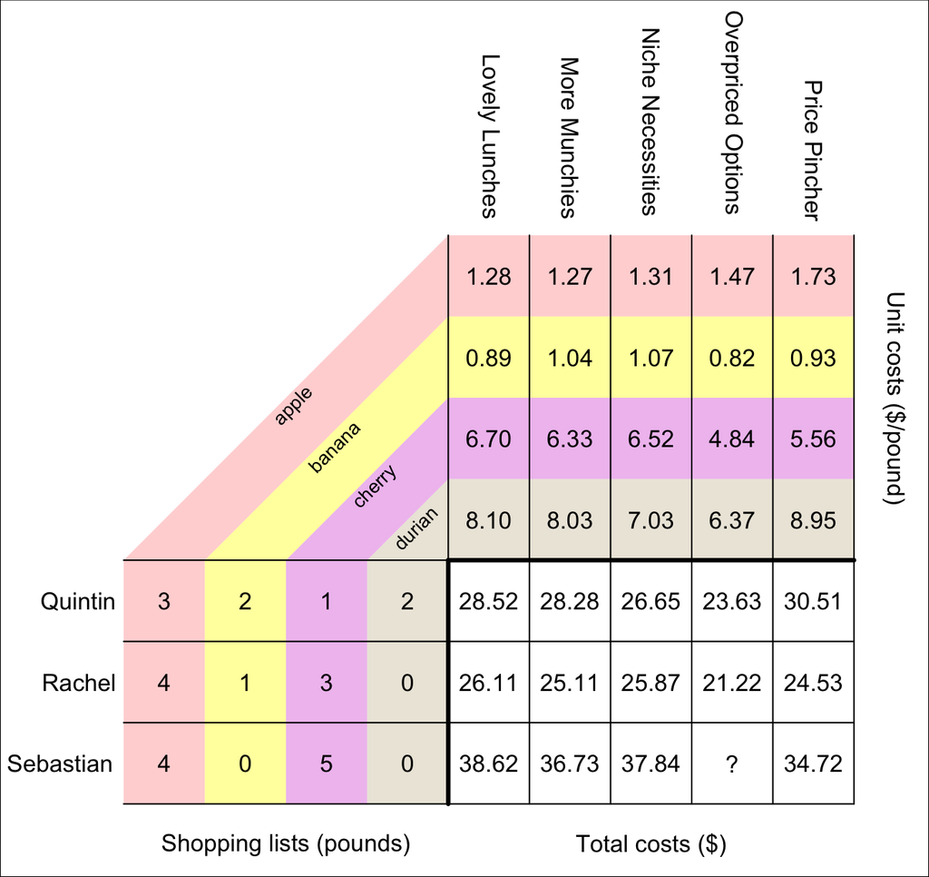

What is the total cost of Sebastian shopping at Overpriced Options?

Sebastian wishes to buy 4 lb of apple, 0 lb of banana, 5 lb of cherry, and 0 lb of durian. At Overpriced Options, the unit price of apple is $1.47/lb, the unit price of banana is $0.82/lb, the unit price of cherry is $4.84/lb, and the unit price of durian is $6.37/lb.

To find the total cost of Sebastian's shopping trip, multiply each quantity by its corresponding unit price and then add up all those products.

$$(4\cdot1.47)~+~(0\cdot0.82)~+~(5\cdot4.84)~+~(0\cdot6.37)$$
$$5.88~+~0~+~24.2~+~0$$
$$30.08$$

So, the total cost of Sebastian shopping at Overpriced Options is $30.08.

In standard math notation, the matrix multiplication would be shown as:

$$\begin{bmatrix}
3 & 2 & 1 & 2\\
4 & 1 & 3 & 0\\
4 & 0 & 5 & 0
\end{bmatrix} \cdot \begin{bmatrix}
1.28 & 1.27 & 1.31 & 1.47 & 1.73\\
0.89 & 1.04 & 1.07 & 0.82 & 0.93\\
6.7 & 6.33 & 6.52 & 4.84 & 5.56\\
8.1 & 8.03 & 7.03 & 6.37 & 8.95
\end{bmatrix} ~=~ \begin{bmatrix}
28.52 & 28.28 & 26.65 & 23.63 & 30.51\\
26.11 & 25.11 & 25.87 & 21.22 & 24.53\\
38.62 & 36.73 & 37.84 & 30.08 & 34.72
\end{bmatrix}$$

Three people are buying fruit, and there are five grocery stores. Each person has a shopping list dictating how many pounds of each fruit to buy. Each store has different unit costs of fruit.

In order to consider the **total** cost for each person at each store, we can use [matrix multiplication](https://en.wikipedia.org/wiki/Matrix_multiplication). In order to help visualize matrix multiplication, the shopping lists are shown as a matrix on the bottom-left, the unit prices as a matrix on top-right, and the resulting matrix of totals in the bottom-right.

A peculiarity of matrix multiplication requires the **columns** of the first matrix to "match" the **rows** of the second matrix. In this case, notice the various fruits correspond to columns in the first matrix (bottom-left) and rows in the second matrix (top-right). This visualization is an attempt to make this seem more natural.

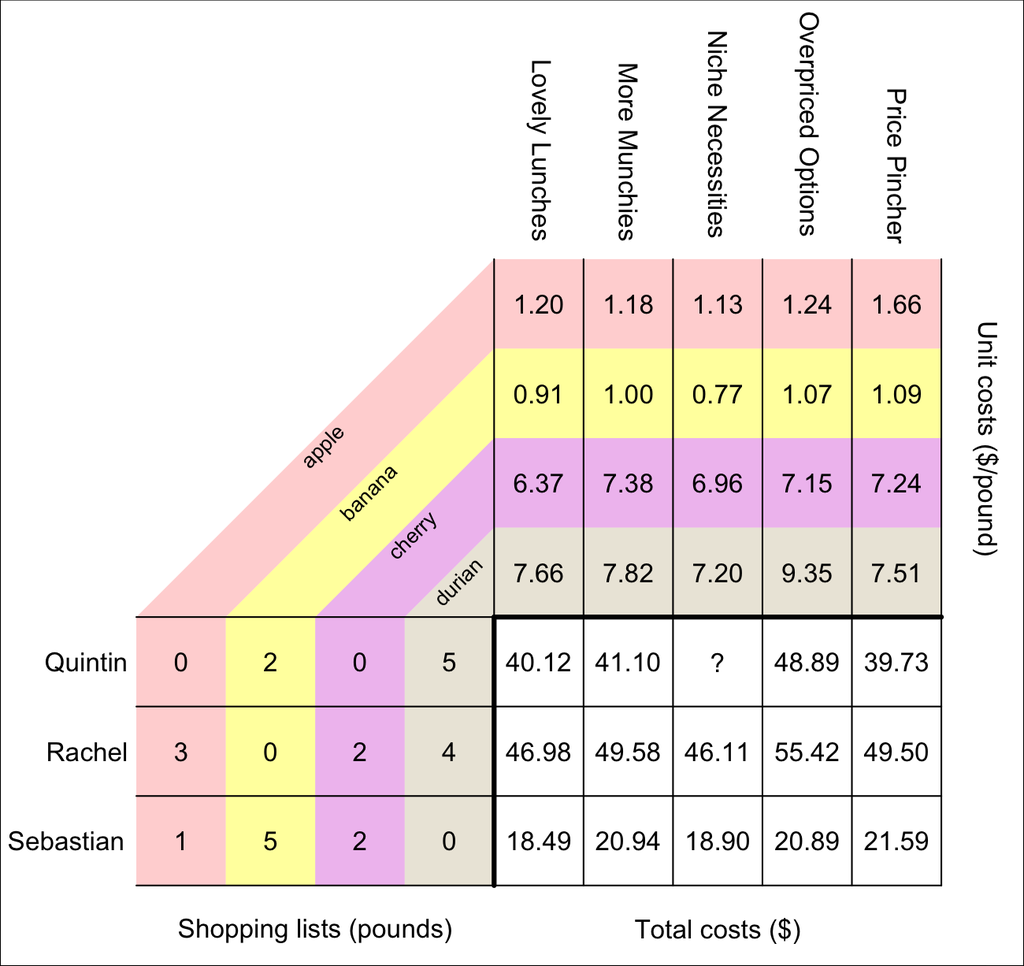

What is the total cost of Quintin shopping at Niche Necessities?

Quintin wishes to buy 0 lb of apple, 2 lb of banana, 0 lb of cherry, and 5 lb of durian. At Niche Necessities, the unit price of apple is $1.13/lb, the unit price of banana is $0.77/lb, the unit price of cherry is $6.96/lb, and the unit price of durian is $7.20/lb.

To find the total cost of Quintin's shopping trip, multiply each quantity by its corresponding unit price and then add up all those products.

$$(0\cdot1.13)~+~(2\cdot0.77)~+~(0\cdot6.96)~+~(5\cdot7.2)$$
$$0~+~1.54~+~0~+~36$$
$$37.54$$

So, the total cost of Quintin shopping at Niche Necessities is $37.54.

In standard math notation, the matrix multiplication would be shown as:

$$\begin{bmatrix}
0 & 2 & 0 & 5\\
3 & 0 & 2 & 4\\
1 & 5 & 2 & 0
\end{bmatrix} \cdot \begin{bmatrix}
1.2 & 1.18 & 1.13 & 1.24 & 1.66\\
0.91 & 1 & 0.77 & 1.07 & 1.09\\
6.37 & 7.38 & 6.96 & 7.15 & 7.24\\
7.66 & 7.82 & 7.2 & 9.35 & 7.51
\end{bmatrix} ~=~ \begin{bmatrix}
40.12 & 41.1 & 37.54 & 48.89 & 39.73\\
46.98 & 49.58 & 46.11 & 55.42 & 49.5\\
18.49 & 20.94 & 18.9 & 20.89 & 21.59
\end{bmatrix}$$

Three people are buying fruit, and there are five grocery stores. Each person has a shopping list dictating how many pounds of each fruit to buy. Each store has different unit costs of fruit.

In order to consider the **total** cost for each person at each store, we can use [matrix multiplication](https://en.wikipedia.org/wiki/Matrix_multiplication). In order to help visualize matrix multiplication, the shopping lists are shown as a matrix on the bottom-left, the unit prices as a matrix on top-right, and the resulting matrix of totals in the bottom-right.

A peculiarity of matrix multiplication requires the **columns** of the first matrix to "match" the **rows** of the second matrix. In this case, notice the various fruits correspond to columns in the first matrix (bottom-left) and rows in the second matrix (top-right). This visualization is an attempt to make this seem more natural.

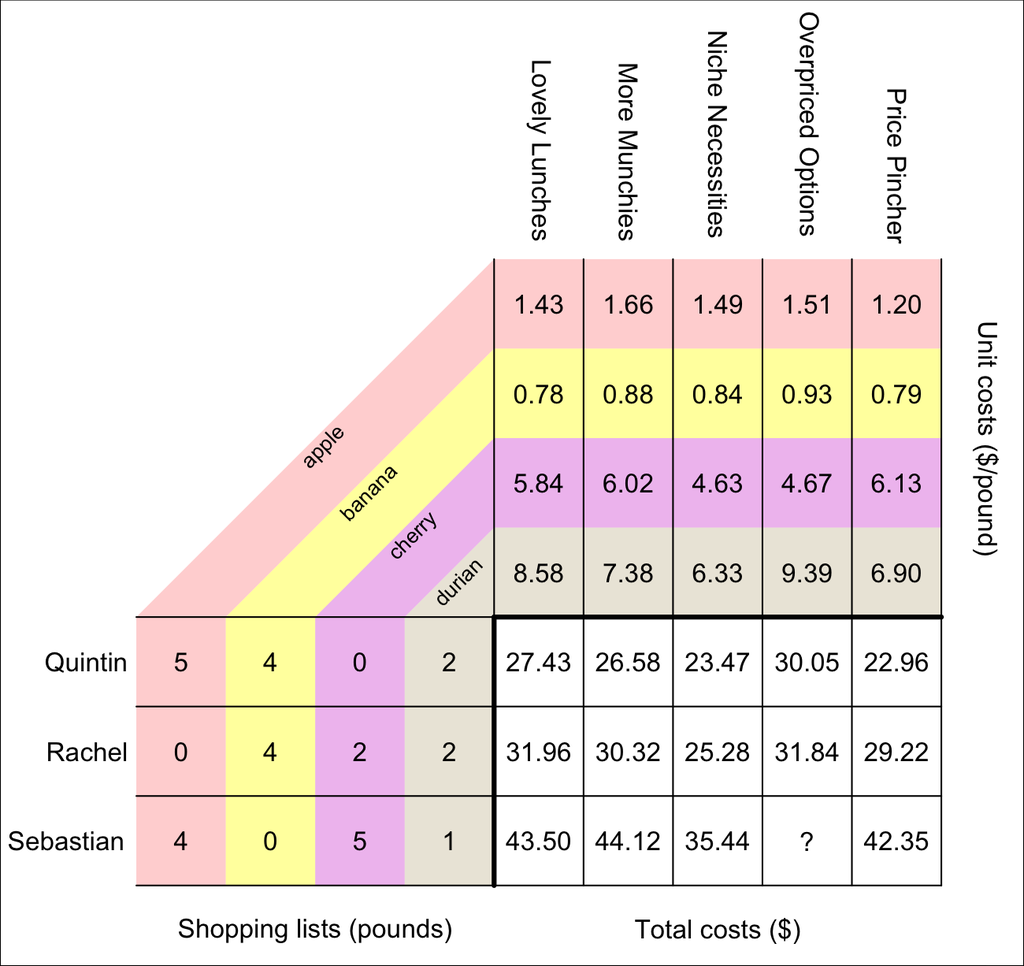

What is the total cost of Sebastian shopping at Overpriced Options?

Sebastian wishes to buy 4 lb of apple, 0 lb of banana, 5 lb of cherry, and 1 lb of durian. At Overpriced Options, the unit price of apple is $1.51/lb, the unit price of banana is $0.93/lb, the unit price of cherry is $4.67/lb, and the unit price of durian is $9.39/lb.

To find the total cost of Sebastian's shopping trip, multiply each quantity by its corresponding unit price and then add up all those products.

$$(4\cdot1.51)~+~(0\cdot0.93)~+~(5\cdot4.67)~+~(1\cdot9.39)$$
$$6.04~+~0~+~23.35~+~9.39$$
$$38.78$$

So, the total cost of Sebastian shopping at Overpriced Options is $38.78.

In standard math notation, the matrix multiplication would be shown as:

$$\begin{bmatrix}
5 & 4 & 0 & 2\\
0 & 4 & 2 & 2\\
4 & 0 & 5 & 1
\end{bmatrix} \cdot \begin{bmatrix}
1.43 & 1.66 & 1.49 & 1.51 & 1.2\\
0.78 & 0.88 & 0.84 & 0.93 & 0.79\\
5.84 & 6.02 & 4.63 & 4.67 & 6.13\\
8.58 & 7.38 & 6.33 & 9.39 & 6.9
\end{bmatrix} ~=~ \begin{bmatrix}
27.43 & 26.58 & 23.47 & 30.05 & 22.96\\
31.96 & 30.32 & 25.28 & 31.84 & 29.22\\
43.5 & 44.12 & 35.44 & 38.78 & 42.35
\end{bmatrix}$$

Three people are buying fruit, and there are five grocery stores. Each person has a shopping list dictating how many pounds of each fruit to buy. Each store has different unit costs of fruit.

In order to consider the **total** cost for each person at each store, we can use [matrix multiplication](https://en.wikipedia.org/wiki/Matrix_multiplication). In order to help visualize matrix multiplication, the shopping lists are shown as a matrix on the bottom-left, the unit prices as a matrix on top-right, and the resulting matrix of totals in the bottom-right.

A peculiarity of matrix multiplication requires the **columns** of the first matrix to "match" the **rows** of the second matrix. In this case, notice the various fruits correspond to columns in the first matrix (bottom-left) and rows in the second matrix (top-right). This visualization is an attempt to make this seem more natural.

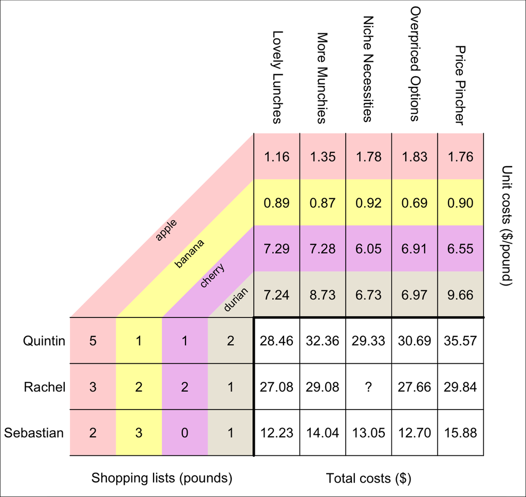

What is the total cost of Rachel shopping at Niche Necessities?

Rachel wishes to buy 3 lb of apple, 2 lb of banana, 2 lb of cherry, and 1 lb of durian. At Niche Necessities, the unit price of apple is $1.78/lb, the unit price of banana is $0.92/lb, the unit price of cherry is $6.05/lb, and the unit price of durian is $6.73/lb.

To find the total cost of Rachel's shopping trip, multiply each quantity by its corresponding unit price and then add up all those products.

$$(3\cdot1.78)~+~(2\cdot0.92)~+~(2\cdot6.05)~+~(1\cdot6.73)$$
$$5.34~+~1.84~+~12.1~+~6.73$$
$$26.01$$

So, the total cost of Rachel shopping at Niche Necessities is $26.01.

In standard math notation, the matrix multiplication would be shown as:

$$\begin{bmatrix}
5 & 1 & 1 & 2\\
3 & 2 & 2 & 1\\
2 & 3 & 0 & 1
\end{bmatrix} \cdot \begin{bmatrix}
1.16 & 1.35 & 1.78 & 1.83 & 1.76\\
0.89 & 0.87 & 0.92 & 0.69 & 0.9\\
7.29 & 7.28 & 6.05 & 6.91 & 6.55\\
7.24 & 8.73 & 6.73 & 6.97 & 9.66
\end{bmatrix} ~=~ \begin{bmatrix}
28.46 & 32.36 & 29.33 & 30.69 & 35.57\\
27.08 & 29.08 & 26.01 & 27.66 & 29.84\\
12.23 & 14.04 & 13.05 & 12.7 & 15.88
\end{bmatrix}$$

Three people are buying fruit, and there are five grocery stores. Each person has a shopping list dictating how many pounds of each fruit to buy. Each store has different unit costs of fruit.

In order to consider the **total** cost for each person at each store, we can use [matrix multiplication](https://en.wikipedia.org/wiki/Matrix_multiplication). In order to help visualize matrix multiplication, the shopping lists are shown as a matrix on the bottom-left, the unit prices as a matrix on top-right, and the resulting matrix of totals in the bottom-right.

A peculiarity of matrix multiplication requires the **columns** of the first matrix to "match" the **rows** of the second matrix. In this case, notice the various fruits correspond to columns in the first matrix (bottom-left) and rows in the second matrix (top-right). This visualization is an attempt to make this seem more natural.

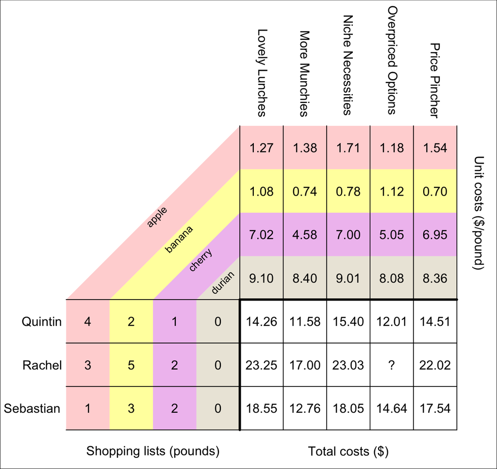

What is the total cost of Rachel shopping at Overpriced Options?

Rachel wishes to buy 3 lb of apple, 5 lb of banana, 2 lb of cherry, and 0 lb of durian. At Overpriced Options, the unit price of apple is $1.18/lb, the unit price of banana is $1.12/lb, the unit price of cherry is $5.05/lb, and the unit price of durian is $8.08/lb.

To find the total cost of Rachel's shopping trip, multiply each quantity by its corresponding unit price and then add up all those products.

$$(3\cdot1.18)~+~(5\cdot1.12)~+~(2\cdot5.05)~+~(0\cdot8.08)$$
$$3.54~+~5.6~+~10.1~+~0$$
$$19.24$$

So, the total cost of Rachel shopping at Overpriced Options is $19.24.

In standard math notation, the matrix multiplication would be shown as:

$$\begin{bmatrix}
4 & 2 & 1 & 0\\
3 & 5 & 2 & 0\\
1 & 3 & 2 & 0
\end{bmatrix} \cdot \begin{bmatrix}
1.27 & 1.38 & 1.71 & 1.18 & 1.54\\
1.08 & 0.74 & 0.78 & 1.12 & 0.7\\
7.02 & 4.58 & 7 & 5.05 & 6.95\\
9.1 & 8.4 & 9.01 & 8.08 & 8.36
\end{bmatrix} ~=~ \begin{bmatrix}
14.26 & 11.58 & 15.4 & 12.01 & 14.51\\
23.25 & 17 & 23.03 & 19.24 & 22.02\\
18.55 & 12.76 & 18.05 & 14.64 & 17.54
\end{bmatrix}$$

Three people are buying fruit, and there are five grocery stores. Each person has a shopping list dictating how many pounds of each fruit to buy. Each store has different unit costs of fruit.

In order to consider the **total** cost for each person at each store, we can use [matrix multiplication](https://en.wikipedia.org/wiki/Matrix_multiplication). In order to help visualize matrix multiplication, the shopping lists are shown as a matrix on the bottom-left, the unit prices as a matrix on top-right, and the resulting matrix of totals in the bottom-right.

A peculiarity of matrix multiplication requires the **columns** of the first matrix to "match" the **rows** of the second matrix. In this case, notice the various fruits correspond to columns in the first matrix (bottom-left) and rows in the second matrix (top-right). This visualization is an attempt to make this seem more natural.

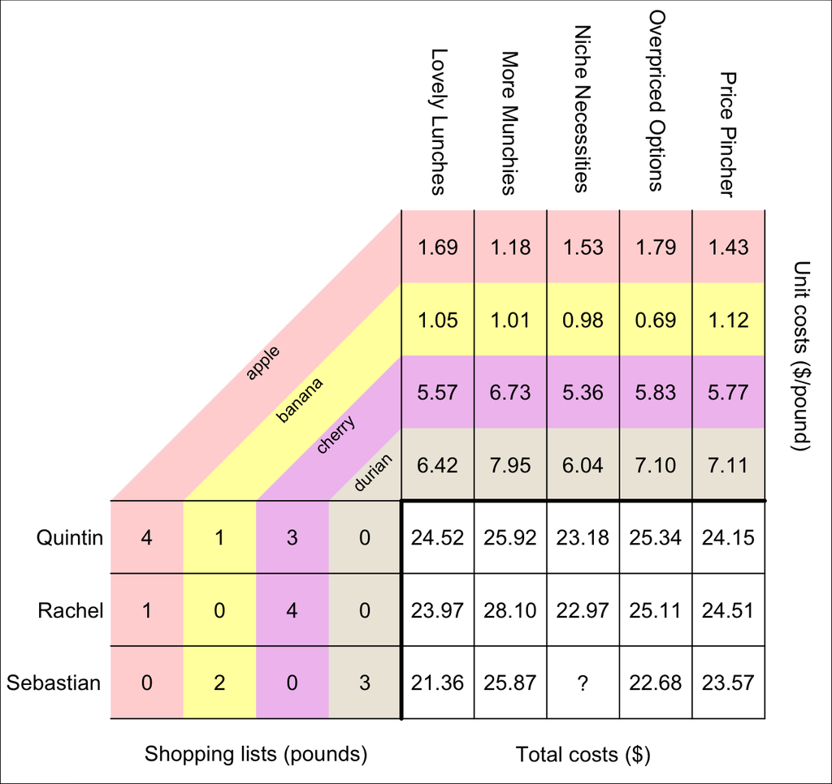

What is the total cost of Sebastian shopping at Niche Necessities?

Sebastian wishes to buy 0 lb of apple, 2 lb of banana, 0 lb of cherry, and 3 lb of durian. At Niche Necessities, the unit price of apple is $1.53/lb, the unit price of banana is $0.98/lb, the unit price of cherry is $5.36/lb, and the unit price of durian is $6.04/lb.

To find the total cost of Sebastian's shopping trip, multiply each quantity by its corresponding unit price and then add up all those products.

$$(0\cdot1.53)~+~(2\cdot0.98)~+~(0\cdot5.36)~+~(3\cdot6.04)$$
$$0~+~1.96~+~0~+~18.12$$
$$20.08$$

So, the total cost of Sebastian shopping at Niche Necessities is $20.08.

In standard math notation, the matrix multiplication would be shown as:

$$\begin{bmatrix}
4 & 1 & 3 & 0\\
1 & 0 & 4 & 0\\
0 & 2 & 0 & 3
\end{bmatrix} \cdot \begin{bmatrix}
1.69 & 1.18 & 1.53 & 1.79 & 1.43\\
1.05 & 1.01 & 0.98 & 0.69 & 1.12\\
5.57 & 6.73 & 5.36 & 5.83 & 5.77\\
6.42 & 7.95 & 6.04 & 7.1 & 7.11
\end{bmatrix} ~=~ \begin{bmatrix}
24.52 & 25.92 & 23.18 & 25.34 & 24.15\\
23.97 & 28.1 & 22.97 & 25.11 & 24.51\\
21.36 & 25.87 & 20.08 & 22.68 & 23.57
\end{bmatrix}$$

Three people are buying fruit, and there are five grocery stores. Each person has a shopping list dictating how many pounds of each fruit to buy. Each store has different unit costs of fruit.

In order to consider the **total** cost for each person at each store, we can use [matrix multiplication](https://en.wikipedia.org/wiki/Matrix_multiplication). In order to help visualize matrix multiplication, the shopping lists are shown as a matrix on the bottom-left, the unit prices as a matrix on top-right, and the resulting matrix of totals in the bottom-right.

A peculiarity of matrix multiplication requires the **columns** of the first matrix to "match" the **rows** of the second matrix. In this case, notice the various fruits correspond to columns in the first matrix (bottom-left) and rows in the second matrix (top-right). This visualization is an attempt to make this seem more natural.

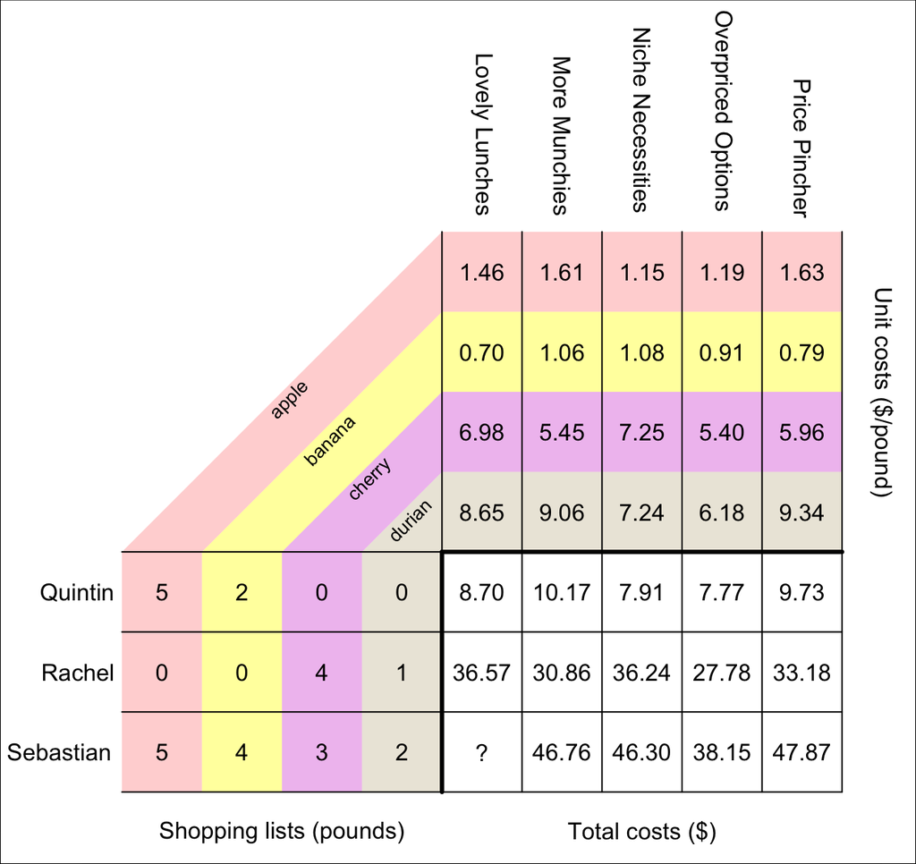

What is the total cost of Sebastian shopping at Lovely Lunches?

Sebastian wishes to buy 5 lb of apple, 4 lb of banana, 3 lb of cherry, and 2 lb of durian. At Lovely Lunches, the unit price of apple is $1.46/lb, the unit price of banana is $0.70/lb, the unit price of cherry is $6.98/lb, and the unit price of durian is $8.65/lb.

To find the total cost of Sebastian's shopping trip, multiply each quantity by its corresponding unit price and then add up all those products.

$$(5\cdot1.46)~+~(4\cdot0.7)~+~(3\cdot6.98)~+~(2\cdot8.65)$$
$$7.3~+~2.8~+~20.94~+~17.3$$
$$48.34$$

So, the total cost of Sebastian shopping at Lovely Lunches is $48.34.

In standard math notation, the matrix multiplication would be shown as:

$$\begin{bmatrix}
5 & 2 & 0 & 0\\
0 & 0 & 4 & 1\\
5 & 4 & 3 & 2
\end{bmatrix} \cdot \begin{bmatrix}
1.46 & 1.61 & 1.15 & 1.19 & 1.63\\
0.7 & 1.06 & 1.08 & 0.91 & 0.79\\
6.98 & 5.45 & 7.25 & 5.4 & 5.96\\
8.65 & 9.06 & 7.24 & 6.18 & 9.34
\end{bmatrix} ~=~ \begin{bmatrix}
8.7 & 10.17 & 7.91 & 7.77 & 9.73\\
36.57 & 30.86 & 36.24 & 27.78 & 33.18\\
48.34 & 46.76 & 46.3 & 38.15 & 47.87
\end{bmatrix}$$

Three people are buying fruit, and there are five grocery stores. Each person has a shopping list dictating how many pounds of each fruit to buy. Each store has different unit costs of fruit.

In order to consider the **total** cost for each person at each store, we can use [matrix multiplication](https://en.wikipedia.org/wiki/Matrix_multiplication). In order to help visualize matrix multiplication, the shopping lists are shown as a matrix on the bottom-left, the unit prices as a matrix on top-right, and the resulting matrix of totals in the bottom-right.

A peculiarity of matrix multiplication requires the **columns** of the first matrix to "match" the **rows** of the second matrix. In this case, notice the various fruits correspond to columns in the first matrix (bottom-left) and rows in the second matrix (top-right). This visualization is an attempt to make this seem more natural.

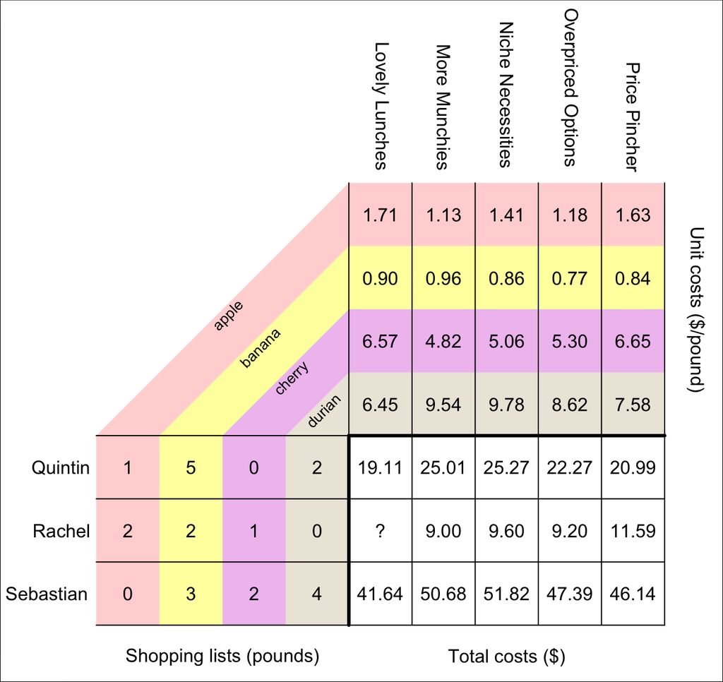

What is the total cost of Rachel shopping at Lovely Lunches?

Rachel wishes to buy 2 lb of apple, 2 lb of banana, 1 lb of cherry, and 0 lb of durian. At Lovely Lunches, the unit price of apple is $1.71/lb, the unit price of banana is $0.90/lb, the unit price of cherry is $6.57/lb, and the unit price of durian is $6.45/lb.

To find the total cost of Rachel's shopping trip, multiply each quantity by its corresponding unit price and then add up all those products.

$$(2\cdot1.71)~+~(2\cdot0.9)~+~(1\cdot6.57)~+~(0\cdot6.45)$$
$$3.42~+~1.8~+~6.57~+~0$$
$$11.79$$

So, the total cost of Rachel shopping at Lovely Lunches is $11.79.

In standard math notation, the matrix multiplication would be shown as:

$$\begin{bmatrix}
1 & 5 & 0 & 2\\
2 & 2 & 1 & 0\\
0 & 3 & 2 & 4
\end{bmatrix} \cdot \begin{bmatrix}
1.71 & 1.13 & 1.41 & 1.18 & 1.63\\
0.9 & 0.96 & 0.86 & 0.77 & 0.84\\
6.57 & 4.82 & 5.06 & 5.3 & 6.65\\
6.45 & 9.54 & 9.78 & 8.62 & 7.58
\end{bmatrix} ~=~ \begin{bmatrix}
19.11 & 25.01 & 25.27 & 22.27 & 20.99\\
11.79 & 9 & 9.6 & 9.2 & 11.59\\
41.64 & 50.68 & 51.82 & 47.39 & 46.14
\end{bmatrix}$$

Three people are buying fruit, and there are five grocery stores. Each person has a shopping list dictating how many pounds of each fruit to buy. Each store has different unit costs of fruit.

In order to consider the **total** cost for each person at each store, we can use [matrix multiplication](https://en.wikipedia.org/wiki/Matrix_multiplication). In order to help visualize matrix multiplication, the shopping lists are shown as a matrix on the bottom-left, the unit prices as a matrix on top-right, and the resulting matrix of totals in the bottom-right.

A peculiarity of matrix multiplication requires the **columns** of the first matrix to "match" the **rows** of the second matrix. In this case, notice the various fruits correspond to columns in the first matrix (bottom-left) and rows in the second matrix (top-right). This visualization is an attempt to make this seem more natural.

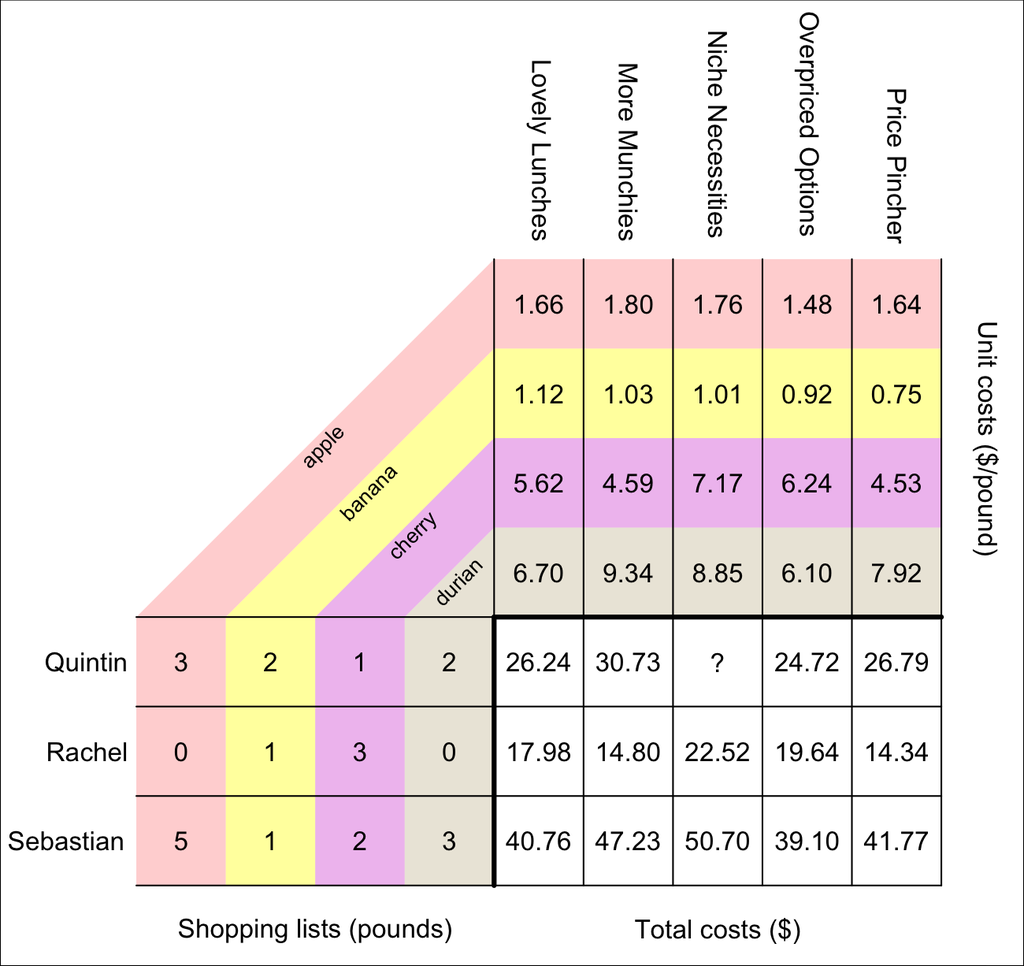

What is the total cost of Quintin shopping at Niche Necessities?

Quintin wishes to buy 3 lb of apple, 2 lb of banana, 1 lb of cherry, and 2 lb of durian. At Niche Necessities, the unit price of apple is $1.76/lb, the unit price of banana is $1.01/lb, the unit price of cherry is $7.17/lb, and the unit price of durian is $8.85/lb.

To find the total cost of Quintin's shopping trip, multiply each quantity by its corresponding unit price and then add up all those products.

$$(3\cdot1.76)~+~(2\cdot1.01)~+~(1\cdot7.17)~+~(2\cdot8.85)$$
$$5.28~+~2.02~+~7.17~+~17.7$$
$$32.17$$

So, the total cost of Quintin shopping at Niche Necessities is $32.17.

In standard math notation, the matrix multiplication would be shown as:

$$\begin{bmatrix}
3 & 2 & 1 & 2\\
0 & 1 & 3 & 0\\
5 & 1 & 2 & 3
\end{bmatrix} \cdot \begin{bmatrix}
1.66 & 1.8 & 1.76 & 1.48 & 1.64\\
1.12 & 1.03 & 1.01 & 0.92 & 0.75\\
5.62 & 4.59 & 7.17 & 6.24 & 4.53\\
6.7 & 9.34 & 8.85 & 6.1 & 7.92
\end{bmatrix} ~=~ \begin{bmatrix}
26.24 & 30.73 & 32.17 & 24.72 & 26.79\\
17.98 & 14.8 & 22.52 & 19.64 & 14.34\\
40.76 & 47.23 & 50.7 & 39.1 & 41.77
\end{bmatrix}$$

Three people are buying fruit, and there are five grocery stores. Each person has a shopping list dictating how many pounds of each fruit to buy. Each store has different unit costs of fruit.

In order to consider the **total** cost for each person at each store, we can use [matrix multiplication](https://en.wikipedia.org/wiki/Matrix_multiplication). In order to help visualize matrix multiplication, the shopping lists are shown as a matrix on the bottom-left, the unit prices as a matrix on top-right, and the resulting matrix of totals in the bottom-right.

A peculiarity of matrix multiplication requires the **columns** of the first matrix to "match" the **rows** of the second matrix. In this case, notice the various fruits correspond to columns in the first matrix (bottom-left) and rows in the second matrix (top-right). This visualization is an attempt to make this seem more natural.

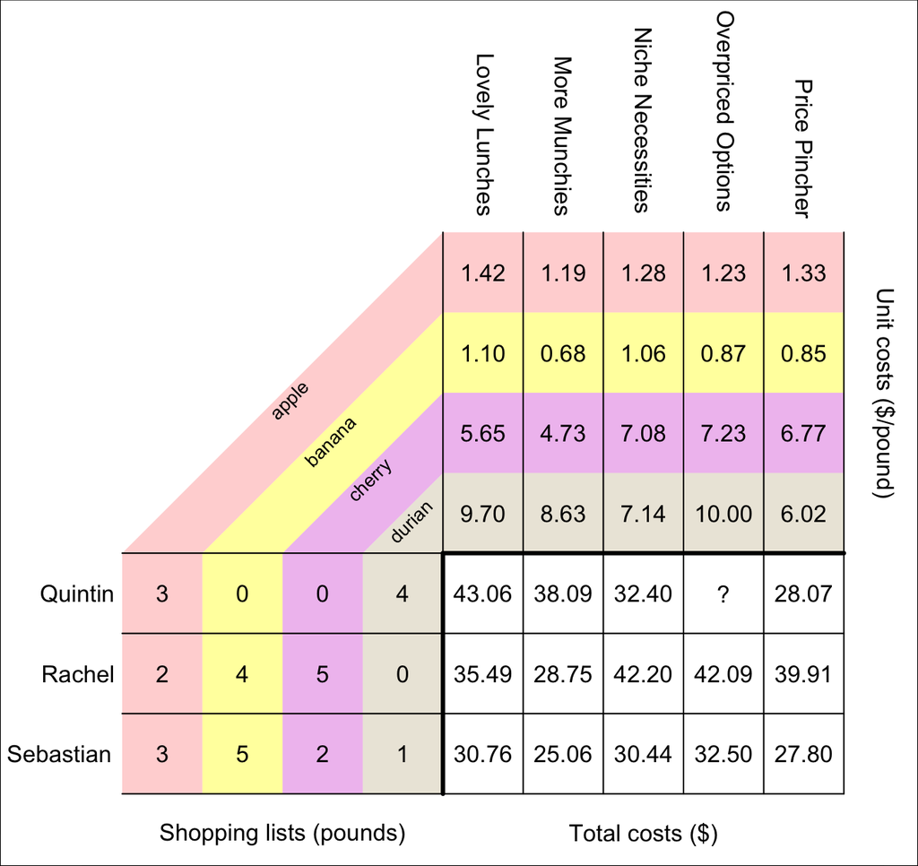

What is the total cost of Quintin shopping at Overpriced Options?

Quintin wishes to buy 3 lb of apple, 0 lb of banana, 0 lb of cherry, and 4 lb of durian. At Overpriced Options, the unit price of apple is $1.23/lb, the unit price of banana is $0.87/lb, the unit price of cherry is $7.23/lb, and the unit price of durian is $10.00/lb.

To find the total cost of Quintin's shopping trip, multiply each quantity by its corresponding unit price and then add up all those products.

$$(3\cdot1.23)~+~(0\cdot0.87)~+~(0\cdot7.23)~+~(4\cdot10)$$
$$3.69~+~0~+~0~+~40$$
$$43.69$$

So, the total cost of Quintin shopping at Overpriced Options is $43.69.

In standard math notation, the matrix multiplication would be shown as:

$$\begin{bmatrix}
3 & 0 & 0 & 4\\
2 & 4 & 5 & 0\\
3 & 5 & 2 & 1
\end{bmatrix} \cdot \begin{bmatrix}
1.42 & 1.19 & 1.28 & 1.23 & 1.33\\
1.1 & 0.68 & 1.06 & 0.87 & 0.85\\
5.65 & 4.73 & 7.08 & 7.23 & 6.77\\
9.7 & 8.63 & 7.14 & 10 & 6.02
\end{bmatrix} ~=~ \begin{bmatrix}
43.06 & 38.09 & 32.4 & 43.69 & 28.07\\
35.49 & 28.75 & 42.2 & 42.09 & 39.91\\
30.76 & 25.06 & 30.44 & 32.5 & 27.8
\end{bmatrix}$$

Three people are buying fruit, and there are five grocery stores. Each person has a shopping list dictating how many pounds of each fruit to buy. Each store has different unit costs of fruit.

In order to consider the **total** cost for each person at each store, we can use [matrix multiplication](https://en.wikipedia.org/wiki/Matrix_multiplication). In order to help visualize matrix multiplication, the shopping lists are shown as a matrix on the bottom-left, the unit prices as a matrix on top-right, and the resulting matrix of totals in the bottom-right.

A peculiarity of matrix multiplication requires the **columns** of the first matrix to "match" the **rows** of the second matrix. In this case, notice the various fruits correspond to columns in the first matrix (bottom-left) and rows in the second matrix (top-right). This visualization is an attempt to make this seem more natural.

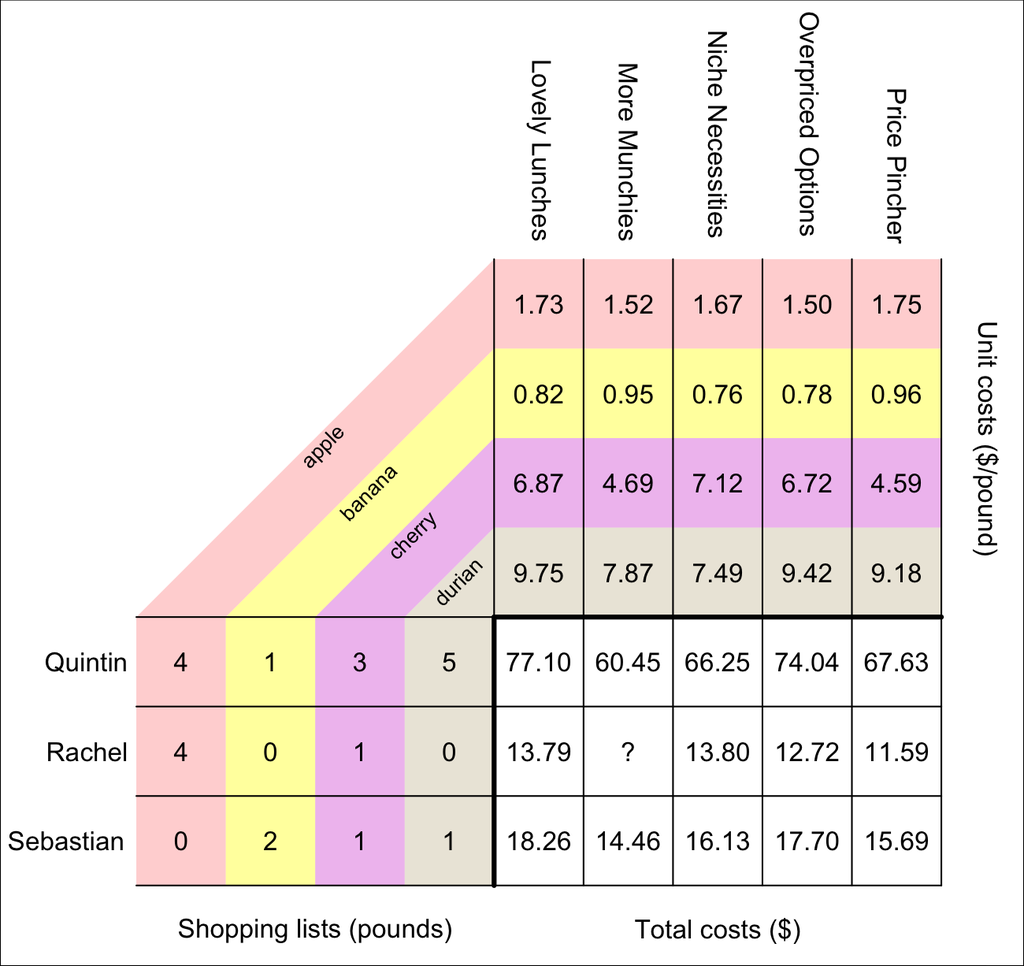

What is the total cost of Rachel shopping at More Munchies?

Rachel wishes to buy 4 lb of apple, 0 lb of banana, 1 lb of cherry, and 0 lb of durian. At More Munchies, the unit price of apple is $1.52/lb, the unit price of banana is $0.95/lb, the unit price of cherry is $4.69/lb, and the unit price of durian is $7.87/lb.

To find the total cost of Rachel's shopping trip, multiply each quantity by its corresponding unit price and then add up all those products.

$$(4\cdot1.52)~+~(0\cdot0.95)~+~(1\cdot4.69)~+~(0\cdot7.87)$$
$$6.08~+~0~+~4.69~+~0$$
$$10.77$$

So, the total cost of Rachel shopping at More Munchies is $10.77.

In standard math notation, the matrix multiplication would be shown as:

$$\begin{bmatrix}
4 & 1 & 3 & 5\\
4 & 0 & 1 & 0\\
0 & 2 & 1 & 1
\end{bmatrix} \cdot \begin{bmatrix}
1.73 & 1.52 & 1.67 & 1.5 & 1.75\\
0.82 & 0.95 & 0.76 & 0.78 & 0.96\\
6.87 & 4.69 & 7.12 & 6.72 & 4.59\\
9.75 & 7.87 & 7.49 & 9.42 & 9.18
\end{bmatrix} ~=~ \begin{bmatrix}
77.1 & 60.45 & 66.25 & 74.04 & 67.63\\
13.79 & 10.77 & 13.8 & 12.72 & 11.59\\
18.26 & 14.46 & 16.13 & 17.7 & 15.69
\end{bmatrix}$$

Three people are buying fruit, and there are five grocery stores. Each person has a shopping list dictating how many pounds of each fruit to buy. Each store has different unit costs of fruit.

In order to consider the **total** cost for each person at each store, we can use [matrix multiplication](https://en.wikipedia.org/wiki/Matrix_multiplication). In order to help visualize matrix multiplication, the shopping lists are shown as a matrix on the bottom-left, the unit prices as a matrix on top-right, and the resulting matrix of totals in the bottom-right.

A peculiarity of matrix multiplication requires the **columns** of the first matrix to "match" the **rows** of the second matrix. In this case, notice the various fruits correspond to columns in the first matrix (bottom-left) and rows in the second matrix (top-right). This visualization is an attempt to make this seem more natural.

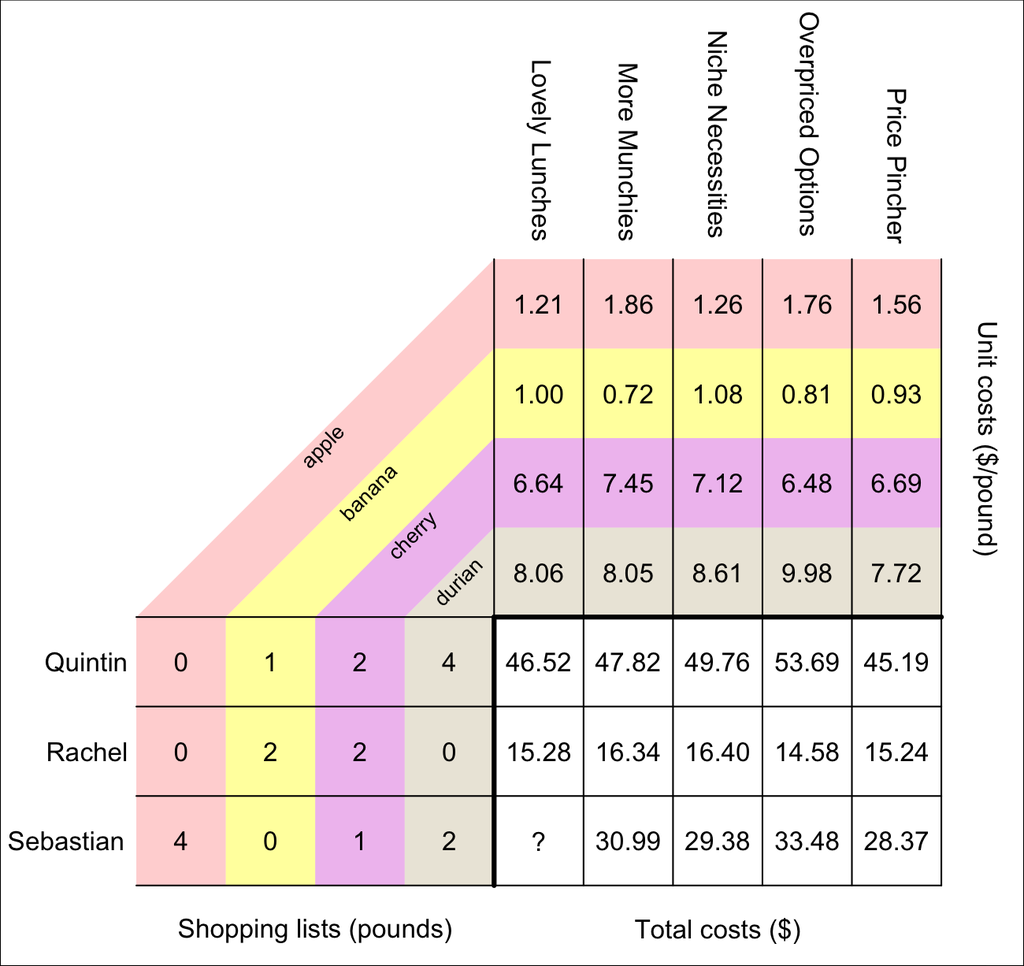

What is the total cost of Sebastian shopping at Lovely Lunches?

Sebastian wishes to buy 4 lb of apple, 0 lb of banana, 1 lb of cherry, and 2 lb of durian. At Lovely Lunches, the unit price of apple is $1.21/lb, the unit price of banana is $1.00/lb, the unit price of cherry is $6.64/lb, and the unit price of durian is $8.06/lb.

To find the total cost of Sebastian's shopping trip, multiply each quantity by its corresponding unit price and then add up all those products.

$$(4\cdot1.21)~+~(0\cdot1)~+~(1\cdot6.64)~+~(2\cdot8.06)$$
$$4.84~+~0~+~6.64~+~16.12$$
$$27.60$$

So, the total cost of Sebastian shopping at Lovely Lunches is $27.60.

In standard math notation, the matrix multiplication would be shown as:

$$\begin{bmatrix}
0 & 1 & 2 & 4\\
0 & 2 & 2 & 0\\
4 & 0 & 1 & 2
\end{bmatrix} \cdot \begin{bmatrix}
1.21 & 1.86 & 1.26 & 1.76 & 1.56\\
1 & 0.72 & 1.08 & 0.81 & 0.93\\
6.64 & 7.45 & 7.12 & 6.48 & 6.69\\
8.06 & 8.05 & 8.61 & 9.98 & 7.72
\end{bmatrix} ~=~ \begin{bmatrix}
46.52 & 47.82 & 49.76 & 53.69 & 45.19\\
15.28 & 16.34 & 16.4 & 14.58 & 15.24\\
27.6 & 30.99 & 29.38 & 33.48 & 28.37
\end{bmatrix}$$